# Analytics Edge: Unit 9 - eHarmony

Sulman Khan

October 26, 2018

## Maximizing the Probability of Love

### About eHarmony

- Goal: take a scientific approach to love and marriage and offer it to the masses through an online dating website focused on extra long term relationships
- Successful at matchmaking
  - Nearly 4% of US marriages in 2012 are a result of eHarmony
- Successful business
  - Has generated over $1 billion in cumulative revenue

### The eHarmony Differences

- Unlike other online dating websites, eHarmony does not have users browse others’ profiles
- Instead, eHarmony computes a compatibility score between two people and uses optimization algorithms to determine their users’ best matches

### eHarmony’s Compatibility Score

- Based on 29 different “dimensions of personality” including character, emotions, values, traits, etc.
- Assessed through a 436 question questionnaire
- Matches must meet >25/29 compatibility areas

### Dr. Neil Clark Warren

- Clinical psychologist who counseled couples and began to see that many marriages ended in divorce because couples were not initially compatible
- Has written many relationship books: “Finding the Love of Your Life”, “The Triumphant Marriage”, “Learning to Live with the Love of Your Life and Loving it”, “Finding Commitment”, and others

### Research -> Business

- In 1997, Warren began an extensive research project interviewing 5000+ couples across the US, which became the basis of eHarmony’s compatibility profile
- www.eHarmony.com went live in 2000
- Interested users may fill out the compatibility quiz, but in order to see matches, members must pay a membership fee to eHarmony

### eHarmony Stands Out From the Crowd

- eHarmony was not the first online dating website and faced serious competition
- Key difference from other dating websites: takes a quantitative optimization approach to matchmaking, rather than letting users browse

### Integer Optimization Example

- Suppose we have three men and three women
- Compatibility score between 1 and 5 for all pairs

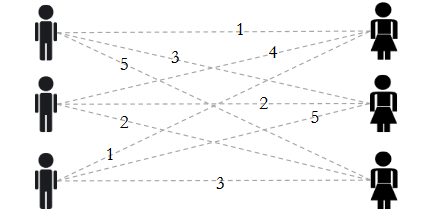

- How should we match pairs together to maximize compatibility?

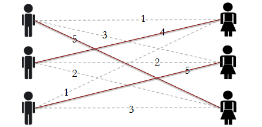

### Data and Decision Variables

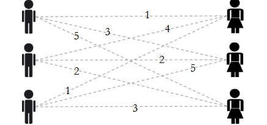

### Objective Function

- Maximize compatibility between matches: max $w_{11}x_{11} + w_{12}x_{12} + w_{13}x_{13} + w_{21}x_{21} + ... + w_{33}x_{33}$

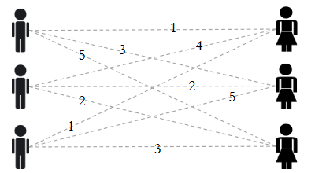

### Constraints

- Match each man to exactly one woman:

$$x_{11} + x_{12} + x_{13} = 1$$

- Similarly, match each woman to exactly one man:

$$x_{11} + x_{21} + x_{31} = 1$$
### Full Optimization Problem

max

$$w_{11}x_{11} + w_{12}x_{12} + w_{13}x_{13} + w_{21}x_{21} + ... + w_{33}x_{33}$$

subject to:

**Match every man to exactly one woman**

$$x_{11} + x_{12} + x_{13} = 1$$
$$x_{21} + x_{22} + x_{23} = 1$$
$$x_{31} + x_{32} + x_{33} = 1$$

** Match every woman to exactly one man**

$$x_{11} + x_{21} + x_{31} = 1$$

$$x_{12} + x_{22} + x_{32} = 1$$

$$x_{13} + x_{23} + x_{33} = 1$$

All are binary variables.

### Extend to Mutliple Matches

- Show woman 1 her top two males matches:

$$x_{11} + x_{21} + x_{31} = 2$$

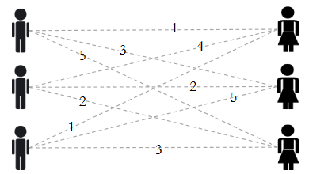

### Compatibility Scores

- In the optimization problem, we assumed the compatibility scores were data that we could input directly into the optimization model
- But where do these scores come from?
- “Opposites attract, then they attack” - Neil Clark Warren
- eHarmony’s compatibility match score is based on similarity between users’ answers to the questionnaire

### Predictive Model

- Public data set from eHarmony containing features for ~275,000 users and binary compatibility results from an interaction suggested by eHarmony
- Feature names and exact values are masked to protect users’ privacy
- Try Logistic regression pairs of users’ differences to predict compatibility

### Reduce the Size of the Problem

- Filtered the data to include only users in the Boston area who had compatibility scores listed in the dataset
- Computed absolute difference in features for these 1475 pairs
- Trained a logistic regression model on these differences

### Prediciting Compatibility is Hard!

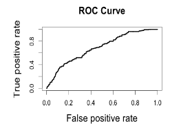

### Other Potential Techniques

- Trees
  - Especially useful for predicting compatibility if there are nonlinear relationships between variables
- Clustering
  - User segmentation
- Text Analytics
  - Analyze the text of users’ profiles
- And much more…

### Feature Importance: Distance

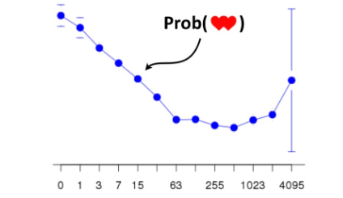

### Feature Importance: Attractiveness

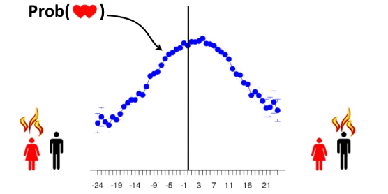

### Feature Importance: Height Differences

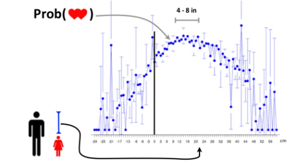

### How Successful is eHarmony?

- By 2004, eHarmony had made over $100 million in sales.
- In 2005, 90 eHarmony members married every day
- In 2007, 236 eHarmony members married every day
- In 2009, 542 eHarmony members married every day

### eHarmony Maintains its Edge

- 14% of the US online dating market.
- The only competitor with a large portion is Match.com with 24%
- Nearly 4% of US marriages in 2012 are a result of eHarmony
- eHarmony has successfully leveraged the power of analytics to create a successful and thriving business